# HW 1 - RMarkdown / Introduction

Your lab/homework must be submitted in Moodle with two files: (1) R Markdown format file (Rmd); (2) an html file. Other formats will not be accepted. Your responses must be supported by both textual explanations and the code you generate to produce your result.

This assignment is designed to train in the usage of RMarkdown, using it to create an HTML document that reflects upon the class discussion of the introduction and Healy’s Chapter 1. The Rmd file in the Moodle folder ‘Lecture 0 - RMarkdown’ is the one used to create the HTML file that is in the same folder.

**Read Chapter 1 from Healy (available in the ‘Readings’ Moodle folder).**

**1. RMarkdown basics**

*1.1* Recreate in RMarkdown the help entry for the `anscombe` dataset. I.e., type `?anscombe` in the console to get the help entry. Recreate the entry in RMarkdown from the title (“Anscombe’s Quartet of ‘Identical’ Simple Linear Regressions”) to the end of the reference section (ends with doi: 10.2307/2682899). You don’t have to have the same fonts, but please use heading styles, make sure the link is alive and note the italics and boldface. In addition, please make sure that the expressions in the “Format” section appear in `inline code` style (e.g. `x1 == x2 == x3`) and in this same section show the three examples in a bullet list.

Add the code from the “Examples” section to your document. I.e. add different portions of the code to different RMarkdown code chunks. Use the `kable` function to show only formatted output (note: annoyingly, `kable` doesn’t show output when called from a for loop. You’ll have to revise the example code a little to make sure you show all the ANOVA tables). Weave the different outputs between text you write that explains what we see. Make sure the figure is aligned to center.

*1.2* Just for fun, place the “Monstrous Costs” figure from Healy here (either find an image online, or print screen and crop). Make sure to align the figure to center, add a caption, and have the width set to 40%.

**2.** Analyze the `gapminder` interactive plot from the introduction.

*2.1* Place here the interactive animated plot from the introduction (you’d need to install and call the libraries `gapminder`, `ggplot2` and `plotly` for it to work). Use the `echo = FALSE` option to hide the code.

*2.2* Without hovering over the markers to show the data that is associated with them, identify a marker that captures your attention (from one of the years). Using the notion of “preattentive search”, try to understand and explain in writing why this particular marker caught your attention. Identify the country that is associated with this marker. Were you surprised? Have you learned something that you didn’t know? Affirmed an intuition? Repeat this exercise, this time with a marker that captures your attention from the animated sequence.

*2.3* For four of the seven “gestalt rules” of your choice that are enumerated in page 22, provide an example of the principle in practice in the gapminder plot. E.g. identify two countries that demonstrate the “closure” idea, and provide two plots (located in the same row in your HTML) where one shows the tooltip for the first country and another the tooltip for a second country. Note that you can also utilize the zoom feature, as well as the box select, lasso select, toggle spike lines, etc. The plots might look like this:

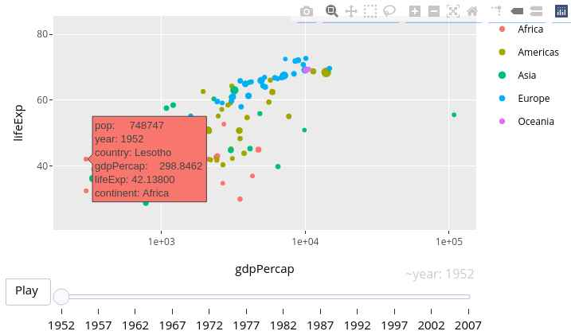

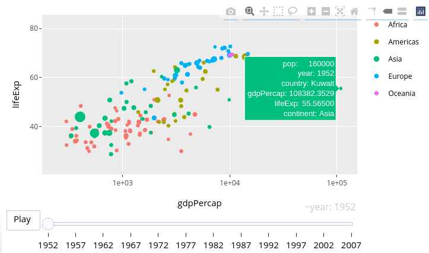

Figure 2.3.1: A short explanation of how Kuwait and Lesotho in 1952 demonstrate a point

*2.4* Starting to think: one thing we mentioned is that the gapminder plot does not highlight “inequality” very well. Visualizing inequalities entails visualizing distributions. Suggest a tentative method for highlighting aspects of inequality in these data that you find important. You may look online, refer to the diamonds app from the introduction or use any other source. You are not asked to provide any plots here, this is a teaser thought experiment (you may provide examples for visualizations you find relevant). We shall discuss visualization tools for comparing distributions at length throughout the class.